# Imputation

Statistical Programming with R

## Working with distributions in `R`

## Sampling from distributions:

In R we can use:

- `rnorm()` to obtain samples from a normal distribution
- `dnorm()` to sample from a normal density function
- `pnorm()` to sample from a normal distribution function
- `qnorm()` to sample from a normal quantile function

This works for other distributions as well, e.g. `rexp()`, `dexp()`, `pexp()` and `qexp()`.

## Setting a seed

```r
set.seed (101)
rnorm(5, 2, 5)
```

```
## [1]  0.3698175  4.7623093 -1.3747192  3.0717973  3.5538461
```

```r
rnorm(5, 2, 5)
```

```
## [1] 7.8698314 5.0939493 1.4363284 6.5851414 0.8837032
```

```r
set.seed(101)
rnorm(5, 2, 5)
```

```
## [1]  0.3698175  4.7623093 -1.3747192  3.0717973  3.5538461
```

## Histograms

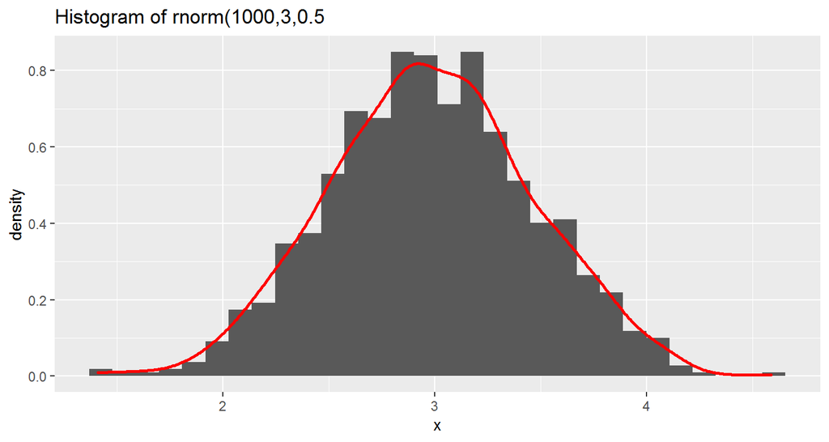

## Code for previous plot

```r
set.seed(101)
tibble( x = rnorm(1000, 3, 0.5)) %>%
  ggplot(aes( x = x))+
  geom_histogram( aes( y = ..density..)) +
  geom_density( col = "red", size = 1) +
  ggtitle("Histogram of rnorm(1000,3,0.5")
```

## Plotting distributions

Using `ggplot` with the `geom_function` geometry

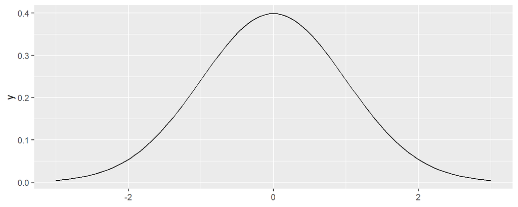

```r
library(ggplot2)
ggplot() + xlim(c(-3,3)) + geom_function( fun = dnorm)
```

## Plotting distributions

Using `ggplot` with the `geom_function` geometry

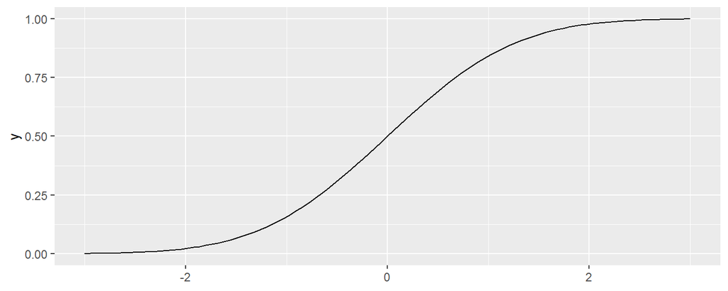

```r
ggplot() + xlim(c(-3,3)) + geom_function( fun = pnorm)
```

## Imputation

## This Lecture:

- Missing data patterns
- Imputation methods
  - `simputation` package

## I use the following packages in this lecture

```r
library(naniar) # additional package for practical
library(simputation) # common interface for several imputation methods
library(tidyverse)
```

## Missing data patterns

## `nhanes` data

`age`: Age group (1=20-39, 2=40-59, 3=60+)

`bmi`: Body mass index (kg/m**2)

`hyp`: High blood pressure, hypertension (1=no,2=yes)

`chl`: Total serum cholesterol (mg/dL)

```r
nhanes <- mice::nhanes

head(nhanes, n = 10)
```

```
##    age  bmi hyp chl
## 1    1   NA  NA  NA
## 2    2 22.7   1 187
## 3    1   NA   1 187
## 4    3   NA  NA  NA
## 5    1 20.4   1 113
## 6    3   NA  NA 184
## 7    1 22.5   1 118
## 8    1 30.1   1 187
## 9    2 22.0   1 238
## 10   2   NA  NA  NA
```

## Exploring missingness patterns

First, a basic dplyr approach:

```r
nhanes %>% is.na() %>% colSums()
```

```
## age bmi hyp chl
##   0   9   8  10
```

## Exploring missingness patterns

Two packages worth mentioning: `VIM` and `naniar` - we will work mainly with `naniar`

```r
miss_var_summary(nhanes)
```

```
## # A tibble: 4 x 3
##   variable n_miss pct_miss
##   <chr>     <int>    <dbl>
## 1 chl          10       40
## 2 bmi           9       36
## 3 hyp           8       32
## 4 age           0        0
```

## Visualise missing data pattern

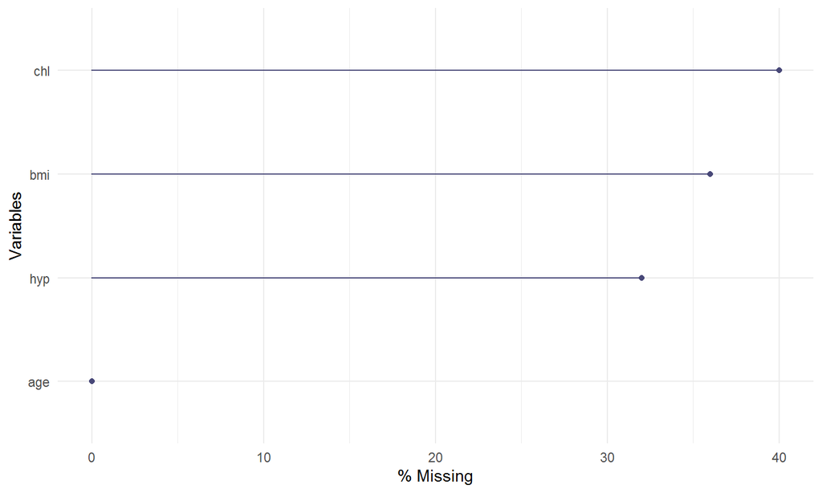

```r
naniar::gg_miss_var(nhanes, show_pct = TRUE)
```

## Visualise missing data pattern

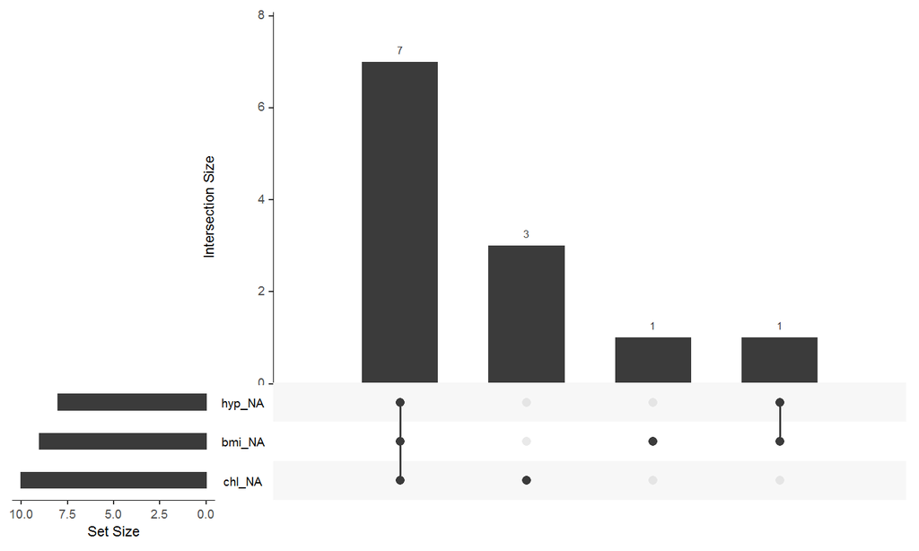

```r
naniar::gg_miss_upset(nhanes)
```

## Visualise missing data pattern by factor variable

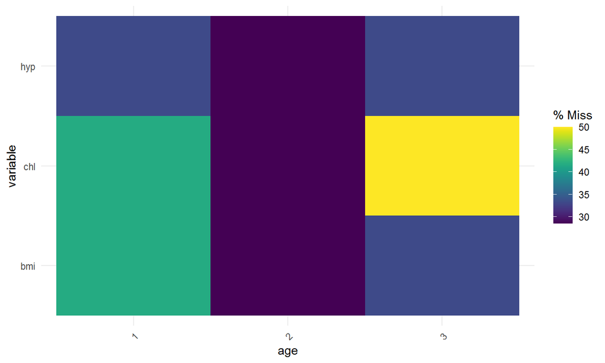

```r
nhanes %>% mutate( age = factor(age)) %>%
  gg_miss_fct(fct = age)
```

## Visualization

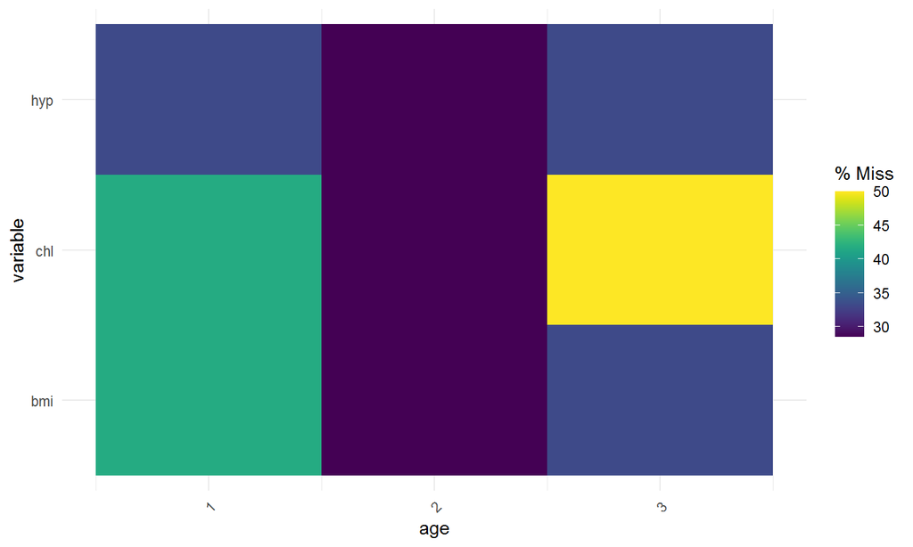

```r
naniar::gg_miss_fct(x = nhanes, fct = age)
```

## Visualization

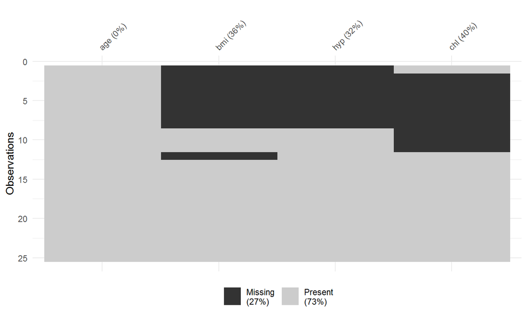

```r
vis_miss(nhanes, cluster= T)
```

## Imputation methods

## Specifying models in `simputation`

Common structure for specifying an imputation model:

```r
impute_<model>(data, formula, [model-specific options])
```

Structure of the model in `formula`:

```r
IMPUTED ~ MODEL_SPECIFICATION [ | GROUPING ]
```

## Regression imputation

```r
imp_1 <- impute_lm(nhanes, bmi ~ age + hyp + chl)
head(imp_1)
```

```
##   age      bmi hyp chl
## 1   1       NA  NA  NA
## 2   2 22.70000   1 187
## 3   1 29.63182   1 187
## 4   3       NA  NA  NA
## 5   1 20.40000   1 113
## 6   3       NA  NA 184
```

```r
head(nhanes)
```

```
##   age  bmi hyp chl
## 1   1   NA  NA  NA
## 2   2 22.7   1 187
## 3   1   NA   1 187
## 4   3   NA  NA  NA
## 5   1 20.4   1 113
## 6   3   NA  NA 184
```

## Median imputation

```r
imp_2 <- impute_median(imp_1, bmi ~ age)
head(imp_2)
```

```
##   age      bmi hyp chl
## 1   1 29.61591  NA  NA
## 2   2 22.70000   1 187
## 3   1 29.63182   1 187
## 4   3 25.20000  NA  NA
## 5   1 20.40000   1 113
## 6   3 25.20000  NA 184
```

```r
imp_2a <- nhanes %>%
          impute_lm(bmi ~ age + hyp + chl) %>%
          impute_median(bmi ~ age)
head(imp_2a)
```

```
##   age      bmi hyp chl
## 1   1 29.61591  NA  NA
## 2   2 22.70000   1 187
## 3   1 29.63182   1 187
## 4   3 25.20000  NA  NA
## 5   1 20.40000   1 113
## 6   3 25.20000  NA 184
```

## Other methods

- `impute_cart()`: decision tree imputation
- `impute_hotdeck()`: random and sequential hot deck, k-nearest neighbours imputation and predictive mean matching.
- `impute_multivariate()`: imputation based on EM-estimation of multivariate normal parameters, imputation based on iterative Random Forest estimates and stochastic imptuation based on bootstrapped EM-estimatin of multivariate normal parameters.
- `impute_proxy()`: Impute missing values by a constant, by copying another variable, computing transformations from other variables.